# linear_model_1

```r
library(tidyverse)
df <- read.csv('cs_1675_fall2021_finalproject.csv')
df <- df %>%
  mutate(x5 = 1 - (x1 + x2 + x3 + x4),
         w = x2 / (x3 + x4),
         z = (x1 + x2) / (x5 + x4),
         t = v1 * v2)
df <- df %>%
  mutate(y = boot::logit(output))
```

**Base Features linear additive model:**

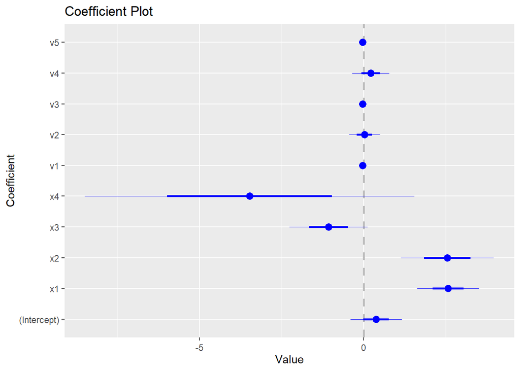

```r
base_additive_model <- df %>% lm(formula = y ~ x1 + x2 + x3 + x4 + v1 + v2 + v3 + v4 + v5)
coefplot::coefplot(base_additive_model)
```

```r
broom::glance(base_additive_model)
```

```
## # A tibble: 1 x 12
##   r.squared adj.r.squared sigma statistic     p.value    df logLik   AIC   BIC
##       <dbl>         <dbl> <dbl>     <dbl>       <dbl> <dbl>  <dbl> <dbl> <dbl>
## 1    0.0379        0.0310  2.28      5.44 0.000000239     9 -2802. 5625. 5682.
## # ... with 3 more variables: deviance <dbl>, df.residual <int>, nobs <int>
```

A very low r-squared. x1 and x2 are the only significant inputs here.

**Base features categorical interaction model:**

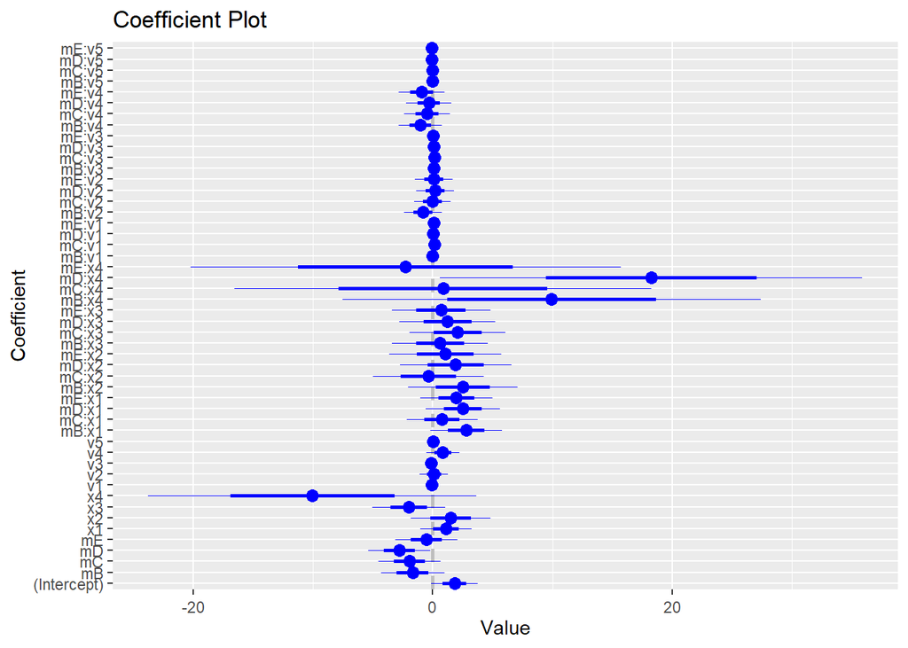

```r
base_categorical_model <- df %>% lm(formula = y ~ m * (x1 + x2 + x3 + x4 + v1 + v2 + v3 + v4 + v5))
coefplot::coefplot(base_categorical_model)
```

```r
summary(base_categorical_model)
```

```
##
## Call:
## lm(formula = y ~ m * (x1 + x2 + x3 + x4 + v1 + v2 + v3 + v4 +
##     v5), data = .)
##
## Residuals:
##     Min      1Q  Median      3Q     Max
## -4.5520 -1.5869 -0.5205  1.0966  8.6244
##
## Coefficients:
##               Estimate Std. Error t value Pr(>|t|)
## (Intercept)  1.815e+00  9.678e-01   1.876   0.0609 .
## mB          -1.677e+00  1.322e+00  -1.268   0.2050
## mC          -1.944e+00  1.303e+00  -1.492   0.1360
## mD          -2.777e+00  1.295e+00  -2.145   0.0322 *
## mE          -5.262e-01  1.297e+00  -0.406   0.6850
## x1           1.115e+00  1.070e+00   1.042   0.2977
## x2           1.489e+00  1.675e+00   0.889   0.3741
## x3          -2.005e+00  1.522e+00  -1.317   0.1879
## x4          -1.006e+01  6.854e+00  -1.468   0.1425
## v1          -8.422e-02  5.596e-02  -1.505   0.1325
## v2           9.985e-02  5.912e-01   0.169   0.8659
## v3          -1.196e-01  6.437e-02  -1.858   0.0634 .
## v4           8.440e-01  6.982e-01   1.209   0.2270
## v5           5.257e-03  4.447e-02   0.118   0.9059
## mB:x1        2.792e+00  1.503e+00   1.857   0.0635 .
## mC:x1        7.738e-01  1.482e+00   0.522   0.6016
## mD:x1        2.505e+00  1.562e+00   1.604   0.1091
## mE:x1        1.964e+00  1.506e+00   1.304   0.1925
## mB:x2        2.513e+00  2.277e+00   1.104   0.2699
## mC:x2       -3.809e-01  2.319e+00  -0.164   0.8696
## mD:x2        1.909e+00  2.328e+00   0.820   0.4122
## mE:x2        1.044e+00  2.346e+00   0.445   0.6565
## mB:x3        6.143e-01  2.003e+00   0.307   0.7592
## mC:x3        2.074e+00  1.996e+00   1.039   0.2991
## mD:x3        1.224e+00  2.013e+00   0.608   0.5431
## mE:x3        6.940e-01  2.053e+00   0.338   0.7353
## mB:x4        9.933e+00  8.733e+00   1.137   0.2556
## mC:x4        8.558e-01  8.703e+00   0.098   0.9217
## mD:x4        1.824e+01  8.815e+00   2.070   0.0387 *
```

[output cut: 12 more lines]

```
## mE:v3        5.036e-02  8.787e-02   0.573   0.5666
## mB:v4       -1.042e+00  9.120e-01  -1.142   0.2536
## mC:v4       -4.611e-01  9.561e-01  -0.482   0.6297
## mD:v4       -3.345e-01  9.410e-01  -0.355   0.7223
## mE:v4       -9.488e-01  9.572e-01  -0.991   0.3218
## mB:v5        6.359e-04  6.259e-02   0.010   0.9919
## mC:v5       -1.356e-02  6.117e-02  -0.222   0.8247
## mD:v5       -8.548e-02  6.211e-02  -1.376   0.1690
## mE:v5       -7.674e-02  6.364e-02  -1.206   0.2281
## ---
## Signif. codes:  0 '***' 0.001 '**' 0.01 '*' 0.05 '.' 0.1 ' ' 1
##
## Residual standard error: 2.274 on 1202 degrees of freedom
## Multiple R-squared:  0.07111,    Adjusted R-squared:  0.03325
## F-statistic: 1.878 on 49 and 1202 DF,  p-value: 0.0002934
```

```r
broom::glance(base_categorical_model)
```

```
## # A tibble: 1 x 12
##   r.squared adj.r.squared sigma statistic  p.value    df logLik   AIC   BIC
##       <dbl>         <dbl> <dbl>     <dbl>    <dbl> <dbl>  <dbl> <dbl> <dbl>
## 1    0.0711        0.0332  2.27      1.88 0.000293    49 -2780. 5662. 5923.
## # ... with 3 more variables: deviance <dbl>, df.residual <int>, nobs <int>
```

Small r-squared again. The significant inputs are mD and mD:x4

**Base pairwise interaction model:**

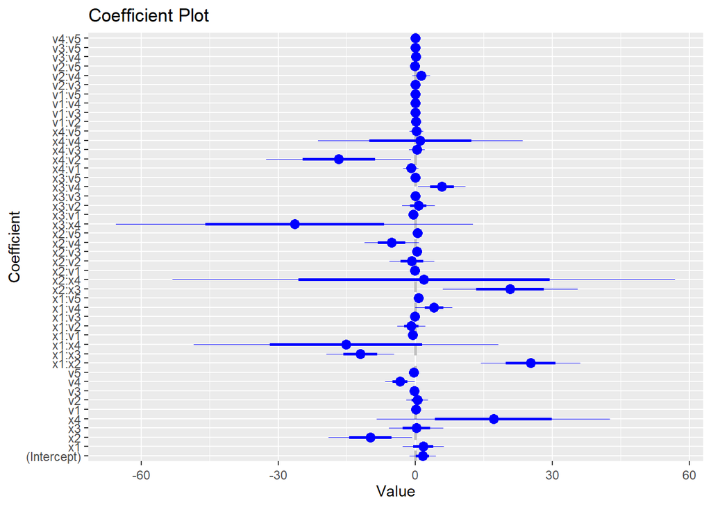

```r
base_pairwise_model <- df %>% lm(formula = y ~ (x1 + x2 + x3 + x4 + v1 + v2 + v3 + v4 + v5)^2)
coefplot::coefplot(base_pairwise_model)
```

```r
summary(base_pairwise_model)
```

```
##
## Call:
## lm(formula = y ~ (x1 + x2 + x3 + x4 + v1 + v2 + v3 + v4 + v5)^2,
##     data = .)
##
## Residuals:
##     Min      1Q  Median      3Q     Max
## -5.1342 -1.4776 -0.5004  1.0474  7.6844
##
## Coefficients:
##               Estimate Std. Error t value Pr(>|t|)
## (Intercept)   1.624553   1.457692   1.114 0.265300
## x1            1.763284   2.253136   0.783 0.434021
## x2           -9.825208   4.594997  -2.138 0.032698 *
## x3            0.231961   2.987775   0.078 0.938130
## x4           17.114223  12.770420   1.340 0.180450
## v1            0.143345   0.125721   1.140 0.254434
## v2            0.457438   1.194871   0.383 0.701910
## v3           -0.215214   0.127566  -1.687 0.091845 .
## v4           -3.307069   1.628057  -2.031 0.042444 *
## v5           -0.268124   0.111608  -2.402 0.016439 *
## x1:x2        25.275784   5.426572   4.658 3.55e-06 ***
## x1:x3       -12.012850   3.718953  -3.230 0.001271 **
## x1:x4       -15.117830  16.680672  -0.906 0.364954
## x1:v1        -0.587504   0.152865  -3.843 0.000128 ***
## x1:v2        -0.862731   1.528046  -0.565 0.572453
## x1:v3        -0.071430   0.168082  -0.425 0.670935
## x1:v4         4.105086   2.026381   2.026 0.043003 *
## x1:v5         0.718460   0.133395   5.386 8.66e-08 ***
## x2:x3        20.782701   7.381603   2.815 0.004950 **
## x2:x4         1.908510  27.500581   0.069 0.944684
## x2:v1        -0.129819   0.259832  -0.500 0.617430
## x2:v2        -0.755509   2.465774  -0.306 0.759354
## x2:v3         0.371931   0.281173   1.323 0.186159
## x2:v4        -5.170391   2.979867  -1.735 0.082977 .
## x2:v5         0.444581   0.202894   2.191 0.028628 *
## x3:x4       -26.404367  19.542116  -1.351 0.176900
## x3:v1        -0.399981   0.188392  -2.123 0.033946 *
## x3:v2         0.703761   1.799642   0.391 0.695825
## x3:v3         0.069826   0.203821   0.343 0.731970
```

[output cut: 8 more lines]

```
## v1:v3         0.007618   0.008010   0.951 0.341754
## v1:v4         0.011161   0.109555   0.102 0.918874
## v1:v5         0.007315   0.006857   1.067 0.286273
## v2:v3         0.003304   0.079726   0.041 0.966955
## v2:v4         1.296929   1.010661   1.283 0.199652
## v2:v5        -0.120182   0.068377  -1.758 0.079063 .
## v3:v4         0.160642   0.115338   1.393 0.163941
## v3:v5        -0.004087   0.007522  -0.543 0.587058
## v4:v5         0.009507   0.087735   0.108 0.913728
## ---
## Signif. codes:  0 '***' 0.001 '**' 0.01 '*' 0.05 '.' 0.1 ' ' 1
##
## Residual standard error: 2.218 on 1206 degrees of freedom
## Multiple R-squared:  0.114,  Adjusted R-squared:  0.08089
## F-statistic: 3.447 on 45 and 1206 DF,  p-value: 5.563e-13
```

```r
broom::glance(base_pairwise_model)
```

```
## # A tibble: 1 x 12
##   r.squared adj.r.squared sigma statistic  p.value    df logLik   AIC   BIC
##       <dbl>         <dbl> <dbl>     <dbl>    <dbl> <dbl>  <dbl> <dbl> <dbl>
## 1     0.114        0.0809  2.22      3.45 5.56e-13    45 -2750. 5594. 5836.
## # ... with 3 more variables: deviance <dbl>, df.residual <int>, nobs <int>
```

Marginally better r-squared, many significant inputs. The most significant are x1:x2, x1:v1, x1:v5.

**Choose expanded feature set:** Based on the correlation plot from data exploration 2, I’ll discard base inputs with high correlation to derived inputs. My expanded feature set is therefore:

x5, w, z, t, x4, v3, v4, v5

**Expanded linear additive model:**

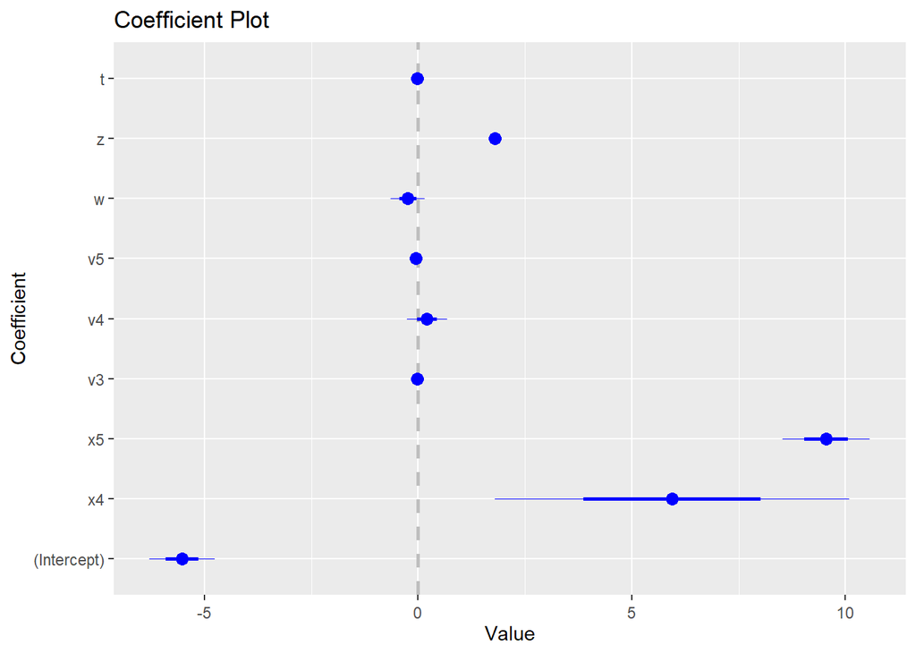

```r
exp_linear_model <- df %>% lm(formula = y ~ x4 + x5 + v3 + v4 + v5 + w + z + t)
coefplot::coefplot(exp_linear_model)
```

```r
summary(exp_linear_model)
```

```
##
## Call:
## lm(formula = y ~ x4 + x5 + v3 + v4 + v5 + w + z + t, data = .)
##
## Residuals:
##     Min      1Q  Median      3Q     Max
## -4.7856 -1.2097 -0.2978  0.8304  7.9277
##
## Coefficients:
##             Estimate Std. Error t value Pr(>|t|)
## (Intercept) -5.51969    0.38261 -14.427  < 2e-16 ***
## x4           5.94393    2.07743   2.861  0.00429 **
## x5           9.54904    0.51092  18.690  < 2e-16 ***
## v3          -0.02068    0.02147  -0.963  0.33559
## v4           0.20800    0.23272   0.894  0.37162
## v5          -0.04679    0.01574  -2.973  0.00300 **
## w           -0.24292    0.19695  -1.233  0.21765
## z            1.79419    0.07146  25.108  < 2e-16 ***
## t           -0.01437    0.02548  -0.564  0.57299
## ---
## Signif. codes:  0 '***' 0.001 '**' 0.01 '*' 0.05 '.' 0.1 ' ' 1
##
## Residual standard error: 1.871 on 1243 degrees of freedom
## Multiple R-squared:  0.3502, Adjusted R-squared:  0.346
## F-statistic: 83.74 on 8 and 1243 DF,  p-value: < 2.2e-16
```

```r
broom::glance(exp_linear_model)
```

```
## # A tibble: 1 x 12
##   r.squared adj.r.squared sigma statistic   p.value    df logLik   AIC   BIC
##       <dbl>         <dbl> <dbl>     <dbl>     <dbl> <dbl>  <dbl> <dbl> <dbl>
## 1     0.350         0.346  1.87      83.7 7.61e-111     8 -2556. 5132. 5183.
## # ... with 3 more variables: deviance <dbl>, df.residual <int>, nobs <int>
```

Significant improvement in r-squared compared to base models, but still low overall. Most significant terms are x5 and z. x4 and v5 also significant.

**Expanded categorical model:**

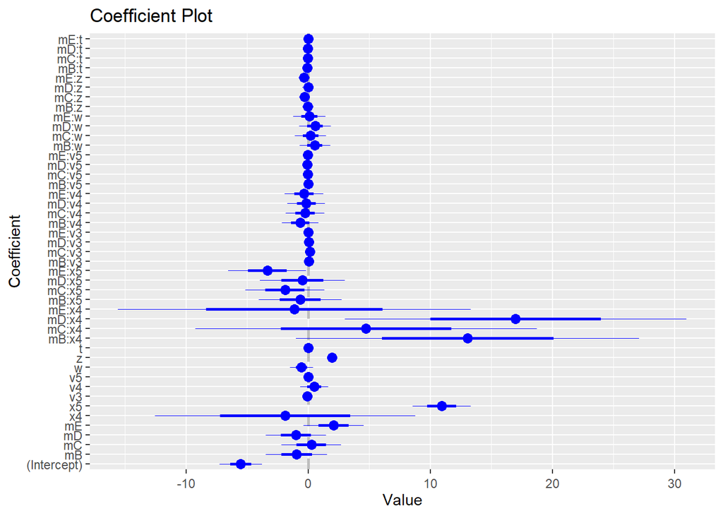

```r
exp_categorical_model <- df %>% lm(formula = y ~ m*(x4 + x5 + v3 + v4 + v5 + w + z + t))
coefplot::coefplot(exp_categorical_model)
```

```r
summary(exp_categorical_model)
```

```
##
## Call:
## lm(formula = y ~ m * (x4 + x5 + v3 + v4 + v5 + w + z + t), data = .)
##
## Residuals:
##     Min      1Q  Median      3Q     Max
## -4.2453 -1.1955 -0.2844  0.8119  7.8483
##
## Coefficients:
##              Estimate Std. Error t value Pr(>|t|)
## (Intercept) -5.524820   0.877825  -6.294 4.33e-10 ***
## mB          -0.956700   1.250073  -0.765   0.4442
## mC           0.248385   1.226136   0.203   0.8395
## mD          -1.015690   1.225580  -0.829   0.4074
## mE           2.083847   1.236679   1.685   0.0922 .
## x4          -1.902601   5.325698  -0.357   0.7210
## x5          10.926455   1.187642   9.200  < 2e-16 ***
## v3          -0.089443   0.051791  -1.727   0.0844 .
## v4           0.502964   0.576077   0.873   0.3828
## v5          -0.013435   0.036647  -0.367   0.7140
## w           -0.554429   0.468356  -1.184   0.2367
## z            1.944181   0.171553  11.333  < 2e-16 ***
## t            0.008393   0.069558   0.121   0.9040
## mB:x4       13.048456   7.030718   1.856   0.0637 .
## mC:x4        4.737958   6.983265   0.678   0.4976
## mD:x4       16.982359   6.995271   2.428   0.0153 *
## mE:x4       -1.130467   7.220710  -0.157   0.8756
## mB:x5       -0.662243   1.689545  -0.392   0.6952
## mC:x5       -1.902382   1.619858  -1.174   0.2405
## mD:x5       -0.476078   1.733353  -0.275   0.7836
## mE:x5       -3.356899   1.591809  -2.109   0.0352 *
## mB:v3        0.069288   0.072595   0.954   0.3401
## mC:v3        0.147271   0.070210   2.098   0.0361 *
## mD:v3        0.061877   0.069243   0.894   0.3717
## mE:v3        0.016253   0.070953   0.229   0.8189
## mB:v4       -0.667017   0.750758  -0.888   0.3745
## mC:v4       -0.258002   0.783569  -0.329   0.7420
## mD:v4       -0.169353   0.773719  -0.219   0.8268
## mE:v4       -0.338883   0.787918  -0.430   0.6672
## mB:v5        0.005016   0.051338   0.098   0.9222
## mC:v5       -0.018513   0.050318  -0.368   0.7130
## mD:v5       -0.068980   0.051002  -1.352   0.1765
## mE:v5       -0.060978   0.052174  -1.169   0.2427
## mB:w         0.544505   0.625746   0.870   0.3844
## mC:w         0.189292   0.644785   0.294   0.7691
## mD:w         0.554822   0.639594   0.867   0.3859
## mE:w         0.087249   0.662694   0.132   0.8953
## mB:z        -0.027839   0.236485  -0.118   0.9063
## mC:z        -0.308367   0.228835  -1.348   0.1781
## mD:z        -0.016614   0.239065  -0.069   0.9446
## mE:z        -0.334939   0.231921  -1.444   0.1489
## mB:t        -0.068123   0.092324  -0.738   0.4607
## mC:t        -0.020657   0.086554  -0.239   0.8114
## mD:t        -0.051699   0.091306  -0.566   0.5714
## mE:t         0.010752   0.086947   0.124   0.9016
## ---
## Signif. codes:  0 '***' 0.001 '**' 0.01 '*' 0.05 '.' 0.1 ' ' 1
##
## Residual standard error: 1.868 on 1207 degrees of freedom
## Multiple R-squared:  0.3706, Adjusted R-squared:  0.3477
## F-statistic: 16.16 on 44 and 1207 DF,  p-value: < 2.2e-16
```

```r
broom::glance(exp_categorical_model)
```

```
## # A tibble: 1 x 12
##   r.squared adj.r.squared sigma statistic  p.value    df logLik   AIC   BIC
##       <dbl>         <dbl> <dbl>     <dbl>    <dbl> <dbl>  <dbl> <dbl> <dbl>
## 1     0.371         0.348  1.87      16.2 2.89e-92    44 -2536. 5164. 5400.
## # ... with 3 more variables: deviance <dbl>, df.residual <int>, nobs <int>
```

Here, the categorical variable doesn’t seem to have a huge effect, as x5 and z are by far the most significant inputs. mD:x4, mE:x5, mC:v3 are also significant, but much less so. Nevertheless, we see marginal improvement in r-squared.

**Expanded pairwise model:**

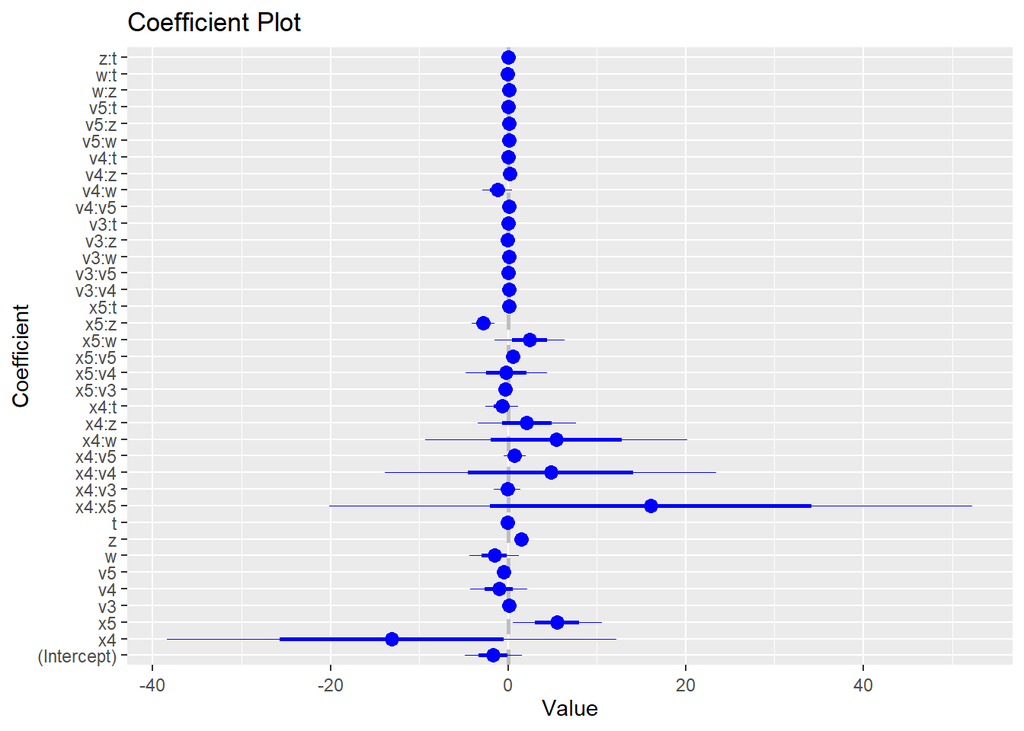

```r
exp_pairwise_model <- df %>% lm(formula = y ~ (x4 + x5 + v3 + v4 + v5 + w + z + t)^2)
coefplot::coefplot(exp_pairwise_model)
```

```r
summary(exp_pairwise_model)
```

```
##
## Call:
## lm(formula = y ~ (x4 + x5 + v3 + v4 + v5 + w + z + t)^2, data = .)
##
## Residuals:
##     Min      1Q  Median      3Q     Max
## -4.7145 -1.1867 -0.2367  0.8949  7.5085
##
## Coefficients:
##               Estimate Std. Error t value Pr(>|t|)
## (Intercept)  -1.672359   1.605168  -1.042 0.297684
## x4          -13.086841  12.638798  -1.035 0.300665
## x5            5.521604   2.512304   2.198 0.028150 *
## v3            0.099127   0.133674   0.742 0.458498
## v4           -1.045861   1.616359  -0.647 0.517723
## v5           -0.473079   0.109550  -4.318 1.70e-05 ***
## w            -1.554492   1.390049  -1.118 0.263660
## z             1.522721   0.346505   4.395 1.21e-05 ***
## t            -0.063039   0.165492  -0.381 0.703330
## x4:x5        16.082700  18.089958   0.889 0.374157
## x4:v3        -0.094697   0.737640  -0.128 0.897871
## x4:v4         4.788758   9.331846   0.513 0.607931
## x4:v5         0.751284   0.614687   1.222 0.221861
## x4:w          5.458250   7.375510   0.740 0.459412
## x4:z          2.110917   2.769202   0.762 0.446039
## x4:t         -0.684935   0.919552  -0.745 0.456502
## x5:v3        -0.332327   0.177398  -1.873 0.061261 .
## x5:v4        -0.189680   2.276586  -0.083 0.933613
## x5:v5         0.557295   0.153020   3.642 0.000282 ***
## x5:w          2.434915   1.974444   1.233 0.217734
## x5:z         -2.790580   0.635171  -4.393 1.21e-05 ***
## x5:t          0.129752   0.206914   0.627 0.530722
## v3:v4         0.125295   0.095111   1.317 0.187971
## v3:v5        -0.002510   0.006211  -0.404 0.686206
## v3:w          0.110548   0.074093   1.492 0.135956
## v3:z         -0.070695   0.027777  -2.545 0.011049 *
## v3:t          0.002205   0.008784   0.251 0.801852
## v4:v5         0.095818   0.072294   1.325 0.185289
## v4:w         -1.210727   0.820202  -1.476 0.140168
## v4:z          0.168567   0.313247   0.538 0.590587
## v4:t          0.046877   0.113754   0.412 0.680347
## v5:w          0.094659   0.058542   1.617 0.106154
## v5:z          0.076337   0.021550   3.542 0.000412 ***
## v5:t          0.003055   0.007352   0.416 0.677784
## w:z           0.088278   0.255390   0.346 0.729658
## w:t          -0.023853   0.086709  -0.275 0.783290
## z:t          -0.002574   0.032202  -0.080 0.936305
## ---
## Signif. codes:  0 '***' 0.001 '**' 0.01 '*' 0.05 '.' 0.1 ' ' 1
##
## Residual standard error: 1.842 on 1215 degrees of freedom
## Multiple R-squared:  0.3842, Adjusted R-squared:  0.366
## F-statistic: 21.06 on 36 and 1215 DF,  p-value: < 2.2e-16
```

```r
broom::glance(exp_pairwise_model)
```

```
## # A tibble: 1 x 12
##   r.squared adj.r.squared sigma statistic   p.value    df logLik   AIC   BIC
##       <dbl>         <dbl> <dbl>     <dbl>     <dbl> <dbl>  <dbl> <dbl> <dbl>
## 1     0.384         0.366  1.84      21.1 8.19e-103    36 -2522. 5121. 5316.
## # ... with 3 more variables: deviance <dbl>, df.residual <int>, nobs <int>
```

Significant inputs include v5, z, x5 (to a lesser degree) and the interactions between them. This is the best model by r-squared thus far.

**Basis function 1** Let’s try a polynomial with significant inputs from above

```r
basis_1 <- df %>% lm(formula = y ~ x1 + x2 + x5 + z + v5 + I(x1^2) + I(x2^2) + I(x5^2) + I(z^2) + I(v5^2))
coefplot::coefplot(basis_1)
summary(basis_1)
```

```
##
## Call:
## lm(formula = y ~ x1 + x2 + x5 + z + v5 + I(x1^2) + I(x2^2) +
##     I(x5^2) + I(z^2) + I(v5^2), data = .)
##
## Residuals:
##     Min      1Q  Median      3Q     Max
## -4.4728 -0.9092  0.0079  0.8492  5.7817
##
## Coefficients:
##               Estimate Std. Error t value Pr(>|t|)
## (Intercept)   1.636554   0.608506   2.689  0.00725 **
## x1          -17.866625   1.280535 -13.952  < 2e-16 ***
## x2           15.400852   1.513737  10.174  < 2e-16 ***
## x5           -0.955513   2.048393  -0.466  0.64096
## z            -2.596072   0.386612  -6.715 2.86e-11 ***
## v5           -0.053438   0.049736  -1.074  0.28283
## I(x1^2)      39.275449   1.602382  24.511  < 2e-16 ***
## I(x2^2)     -31.332356   3.780144  -8.289 2.94e-16 ***
## I(x5^2)       2.572852   1.796988   1.432  0.15246
## I(z^2)        0.669698   0.049518  13.524  < 2e-16 ***
## I(v5^2)       0.003105   0.004576   0.679  0.49755
## ---
## Signif. codes:  0 '***' 0.001 '**' 0.01 '*' 0.05 '.' 0.1 ' ' 1
##
## Residual standard error: 1.388 on 1241 degrees of freedom
## Multiple R-squared:  0.643,  Adjusted R-squared:  0.6401
## F-statistic: 223.5 on 10 and 1241 DF,  p-value: < 2.2e-16
```

```r
broom::glance(basis_1)
```

```
## # A tibble: 1 x 12
##   r.squared adj.r.squared sigma statistic   p.value    df logLik   AIC   BIC
##       <dbl>         <dbl> <dbl>     <dbl>     <dbl> <dbl>  <dbl> <dbl> <dbl>
## 1     0.643         0.640  1.39      223. 3.11e-269    10 -2181. 4386. 4448.
## # ... with 3 more variables: deviance <dbl>, df.residual <int>, nobs <int>
```

**Basis function 2** Okay, how about some splines with the most signficant terms above

```r
basis_2 <- df %>% lm(formula = y ~ splines::ns(x1, df = 12) + splines::ns(x2, df = 12) + splines::ns(z, df = 12) )
coefplot::coefplot(basis_2)
summary(basis_2)
```

```
##
## Call:
## lm(formula = y ~ splines::ns(x1, df = 12) + splines::ns(x2, df = 12) +
##     splines::ns(z, df = 12), data = .)
##
## Residuals:
##     Min      1Q  Median      3Q     Max
## -3.3557 -0.6282  0.0317  0.6647  3.0897
##
## Coefficients:
##                            Estimate Std. Error t value Pr(>|t|)
## (Intercept)                 8.50469    0.35270  24.113  < 2e-16 ***
## splines::ns(x1, df = 12)1  -6.91346    0.28638 -24.140  < 2e-16 ***
## splines::ns(x1, df = 12)2  -6.78512    0.42167 -16.091  < 2e-16 ***
## splines::ns(x1, df = 12)3  -6.67922    0.34090 -19.593  < 2e-16 ***
## splines::ns(x1, df = 12)4  -6.46483    0.40580 -15.931  < 2e-16 ***
## splines::ns(x1, df = 12)5  -5.93562    0.34324 -17.293  < 2e-16 ***
## splines::ns(x1, df = 12)6  -5.49800    0.34777 -15.809  < 2e-16 ***
## splines::ns(x1, df = 12)7  -4.88873    0.36586 -13.362  < 2e-16 ***
## splines::ns(x1, df = 12)8  -4.00942    0.36813 -10.891  < 2e-16 ***
## splines::ns(x1, df = 12)9  -3.85713    0.37709 -10.229  < 2e-16 ***
## splines::ns(x1, df = 12)10  0.43510    0.35636   1.221 0.222336
## splines::ns(x1, df = 12)11 -7.33628    0.66802 -10.982  < 2e-16 ***
## splines::ns(x1, df = 12)12  2.47296    0.31627   7.819 1.15e-14 ***
## splines::ns(x2, df = 12)1  -0.57035    0.23533  -2.424 0.015513 *
## splines::ns(x2, df = 12)2  -0.07227    0.31534  -0.229 0.818754
## splines::ns(x2, df = 12)3   0.18801    0.30756   0.611 0.541113
## splines::ns(x2, df = 12)4   0.84319    0.31911   2.642 0.008339 **
## splines::ns(x2, df = 12)5   1.79354    0.27097   6.619 5.41e-11 ***
## splines::ns(x2, df = 12)6   2.07620    0.29816   6.963 5.43e-12 ***
## splines::ns(x2, df = 12)7   1.92852    0.35557   5.424 7.04e-08 ***
## splines::ns(x2, df = 12)8   1.46348    0.32081   4.562 5.58e-06 ***
## splines::ns(x2, df = 12)9   1.95112    0.27015   7.222 8.98e-13 ***
## splines::ns(x2, df = 12)10  1.69736    0.34467   4.925 9.62e-07 ***
## splines::ns(x2, df = 12)11  1.63663    0.50820   3.220 0.001314 **
## splines::ns(x2, df = 12)12  2.04151    0.43138   4.733 2.48e-06 ***
## splines::ns(z, df = 12)1   -3.44291    0.27101 -12.704  < 2e-16 ***
## splines::ns(z, df = 12)2   -4.20375    0.36579 -11.492  < 2e-16 ***
## splines::ns(z, df = 12)3   -4.62650    0.33801 -13.688  < 2e-16 ***
## splines::ns(z, df = 12)4   -5.44663    0.36756 -14.818  < 2e-16 ***
## splines::ns(z, df = 12)5   -6.32616    0.37910 -16.687  < 2e-16 ***
## splines::ns(z, df = 12)6   -5.60232    0.36352 -15.411  < 2e-16 ***
## splines::ns(z, df = 12)7   -5.52096    0.37714 -14.639  < 2e-16 ***
## splines::ns(z, df = 12)8   -5.11069    0.38609 -13.237  < 2e-16 ***
## splines::ns(z, df = 12)9   -2.91934    0.40002  -7.298 5.26e-13 ***
## splines::ns(z, df = 12)10  -1.40375    0.35059  -4.004 6.61e-05 ***
## splines::ns(z, df = 12)11  -3.19343    0.60640  -5.266 1.65e-07 ***
## splines::ns(z, df = 12)12   1.15637    0.34400   3.362 0.000799 ***
## ---
## Signif. codes:  0 '***' 0.001 '**' 0.01 '*' 0.05 '.' 0.1 ' ' 1
##
## Residual standard error: 0.9648 on 1215 degrees of freedom
## Multiple R-squared:  0.8311, Adjusted R-squared:  0.826
## F-statistic:   166 on 36 and 1215 DF,  p-value: < 2.2e-16
```

```r
broom::glance(basis_2)
```

```
## # A tibble: 1 x 12
##   r.squared adj.r.squared sigma statistic p.value    df logLik   AIC   BIC
##       <dbl>         <dbl> <dbl>     <dbl>   <dbl> <dbl>  <dbl> <dbl> <dbl>
## 1     0.831         0.826 0.965      166.       0    36 -1713. 3502. 3697.
## # ... with 3 more variables: deviance <dbl>, df.residual <int>, nobs <int>
```

Okay this one’s pretty good. High r-squared, lower ICs.

**Basis function 3** Let’s try adding categorical interactions..

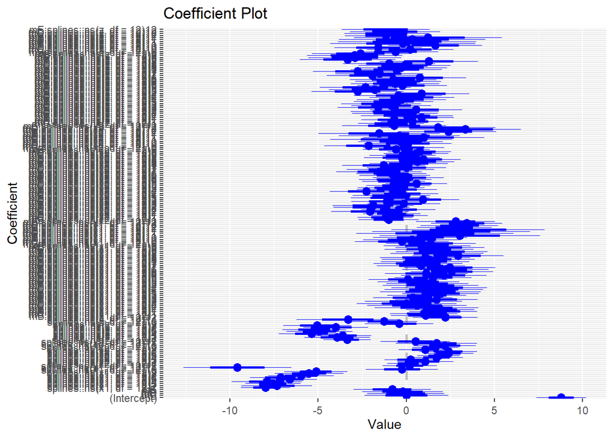

```r
basis_3 <- df %>% lm(formula = y ~ m * (splines::ns(x1, df = 12) + splines::ns(x2, df = 12) + splines::ns(z, df = 12)))
coefplot::coefplot(basis_3)
```

```r
summary(basis_3)
```

```
##
## Call:
## lm(formula = y ~ m * (splines::ns(x1, df = 12) + splines::ns(x2,
##     df = 12) + splines::ns(z, df = 12)), data = .)
##
## Residuals:
##     Min      1Q  Median      3Q     Max
## -3.3096 -0.5841  0.0266  0.6097  3.2592
##
## Coefficients:
##                                Estimate Std. Error t value Pr(>|t|)
## (Intercept)                    8.786173   0.702576  12.506  < 2e-16 ***
## mB                             0.002702   1.189383   0.002 0.998188
## mC                            -0.025682   1.091992  -0.024 0.981241
## mD                            -0.209777   1.145662  -0.183 0.854750
## mE                            -0.799088   1.102188  -0.725 0.468610
## splines::ns(x1, df = 12)1     -7.974521   0.699910 -11.394  < 2e-16 ***
## splines::ns(x1, df = 12)2     -7.337301   1.001721  -7.325 4.71e-13 ***
## splines::ns(x1, df = 12)3     -7.560737   0.779735  -9.697  < 2e-16 ***
## splines::ns(x1, df = 12)4     -7.911932   0.995950  -7.944 4.94e-15 ***
## splines::ns(x1, df = 12)5     -6.601904   0.773618  -8.534  < 2e-16 ***
## splines::ns(x1, df = 12)6     -7.137878   0.860288  -8.297 3.19e-16 ***
## splines::ns(x1, df = 12)7     -5.960477   0.931773  -6.397 2.37e-10 ***
## splines::ns(x1, df = 12)8     -5.513958   0.970693  -5.680 1.73e-08 ***
## splines::ns(x1, df = 12)9     -5.123005   0.895132  -5.723 1.36e-08 ***
## splines::ns(x1, df = 12)10    -0.240832   1.023156  -0.235 0.813958
## splines::ns(x1, df = 12)11    -9.574987   1.534828  -6.238 6.36e-10 ***
## splines::ns(x1, df = 12)12     0.198395   0.768280   0.258 0.796277
## splines::ns(x2, df = 12)1      0.108788   0.587299   0.185 0.853080
## splines::ns(x2, df = 12)2      1.079357   0.794200   1.359 0.174418
## splines::ns(x2, df = 12)3      0.234835   0.738795   0.318 0.750651
## splines::ns(x2, df = 12)4      1.716806   0.747551   2.297 0.021836 *
## splines::ns(x2, df = 12)5      1.840381   0.603039   3.052 0.002331 **
## splines::ns(x2, df = 12)6      2.384988   0.709837   3.360 0.000807 ***
## splines::ns(x2, df = 12)7      2.379465   0.817925   2.909 0.003699 **
## splines::ns(x2, df = 12)8      1.074742   0.748749   1.435 0.151471
## splines::ns(x2, df = 12)9      1.646178   0.653480   2.519 0.011911 *
## splines::ns(x2, df = 12)10     2.185152   0.874922   2.498 0.012656 *
## splines::ns(x2, df = 12)11     1.708699   1.149669   1.486 0.137508
## splines::ns(x2, df = 12)12     0.514792   0.994797   0.517 0.604925
```

[output cut: 147 more lines]

```
## mE:splines::ns(z, df = 12)10   1.643064   1.327906   1.237 0.216235
## mB:splines::ns(z, df = 12)11  -0.202551   2.052077  -0.099 0.921391
## mC:splines::ns(z, df = 12)11   0.047194   1.960552   0.024 0.980800
## mD:splines::ns(z, df = 12)11   0.339754   2.072961   0.164 0.869842
## mE:splines::ns(z, df = 12)11   1.231304   2.092003   0.589 0.556270
## mB:splines::ns(z, df = 12)12  -1.142572   1.172690  -0.974 0.330120
## mC:splines::ns(z, df = 12)12  -1.135724   1.185975  -0.958 0.338467
## mD:splines::ns(z, df = 12)12  -0.642504   1.283881  -0.500 0.616869
## mE:splines::ns(z, df = 12)12  -1.163556   1.249288  -0.931 0.351870
## ---
## Signif. codes:  0 '***' 0.001 '**' 0.01 '*' 0.05 '.' 0.1 ' ' 1
##
## Residual standard error: 0.9582 on 1067 degrees of freedom
## Multiple R-squared:  0.8536, Adjusted R-squared:  0.8284
## F-statistic: 33.82 on 184 and 1067 DF,  p-value: < 2.2e-16
```

```r
broom::glance(basis_3)
```

```
## # A tibble: 1 x 12
##   r.squared adj.r.squared sigma statistic p.value    df logLik   AIC   BIC
##       <dbl>         <dbl> <dbl>     <dbl>   <dbl> <dbl>  <dbl> <dbl> <dbl>
## 1     0.854         0.828 0.958      33.8       0   184 -1623. 3618. 4573.
## # ... with 3 more variables: deviance <dbl>, df.residual <int>, nobs <int>
```

A monstrosity of a model. Slight gains in r-squared at a large cost to BIC, and little growth in adjusted r-squared. I think we went too far…

**Model comparisons:**

```r
bind_rows(
broom::glance(base_additive_model) %>% add_column(name = "Base Additive Model", .before = 1),
broom::glance(base_categorical_model) %>% add_column(name = "Base Categorical Model", .before = 1),
broom::glance(base_pairwise_model) %>% add_column(name = "Base Pairwise Model", .before = 1),
broom::glance(exp_linear_model) %>% add_column(name = "Expanded Additive Model", .before = 1),
broom::glance(exp_categorical_model) %>% add_column(name = "Expanded Categorial Model", .before = 1),
broom::glance(exp_pairwise_model) %>% add_column(name = "Expanded Pairwise Model", .before = 1),
broom::glance(basis_1) %>% add_column(name = "Basis fn Model 1", .before = 1),
broom::glance(basis_2) %>% add_column(name = "Basis fn Model 2", .before = 1),
broom::glance(basis_3) %>% add_column(name = "Basis fn Model 3", .before = 1),
)
```

```
## # A tibble: 9 x 13
##   name      r.squared adj.r.squared sigma statistic   p.value    df logLik   AIC
##   <chr>         <dbl>         <dbl> <dbl>     <dbl>     <dbl> <dbl>  <dbl> <dbl>
## 1 Base Add~    0.0379        0.0310 2.28       5.44 2.39e-  7     9 -2802. 5625.
## 2 Base Cat~    0.0711        0.0332 2.27       1.88 2.93e-  4    49 -2780. 5662.
## 3 Base Pai~    0.114         0.0809 2.22       3.45 5.56e- 13    45 -2750. 5594.
## 4 Expanded~    0.350         0.346  1.87      83.7  7.61e-111     8 -2556. 5132.
## 5 Expanded~    0.371         0.348  1.87      16.2  2.89e- 92    44 -2536. 5164.
## 6 Expanded~    0.384         0.366  1.84      21.1  8.19e-103    36 -2522. 5121.
## 7 Basis fn~    0.643         0.640  1.39     223.   3.11e-269    10 -2181. 4386.
## 8 Basis fn~    0.831         0.826  0.965    166.   0            36 -1713. 3502.
## 9 Basis fn~    0.854         0.828  0.958     33.8  0           184 -1623. 3618.
## # ... with 4 more variables: BIC <dbl>, deviance <dbl>, df.residual <int>,
## #   nobs <int>
```

Of the 9 linear models, Basis Function Model 2 is the best by AIC and BIC, and a very close second by adjusted r-squared. We can also see large jumps in r-squared between each of the 3 categories of model. Basis function Model 3 is the best by r-squared, but is very complex for the marginal performance gains it achieves, and thus suffers in IC scores.

**Top 3 Model Coefficient Summaries**

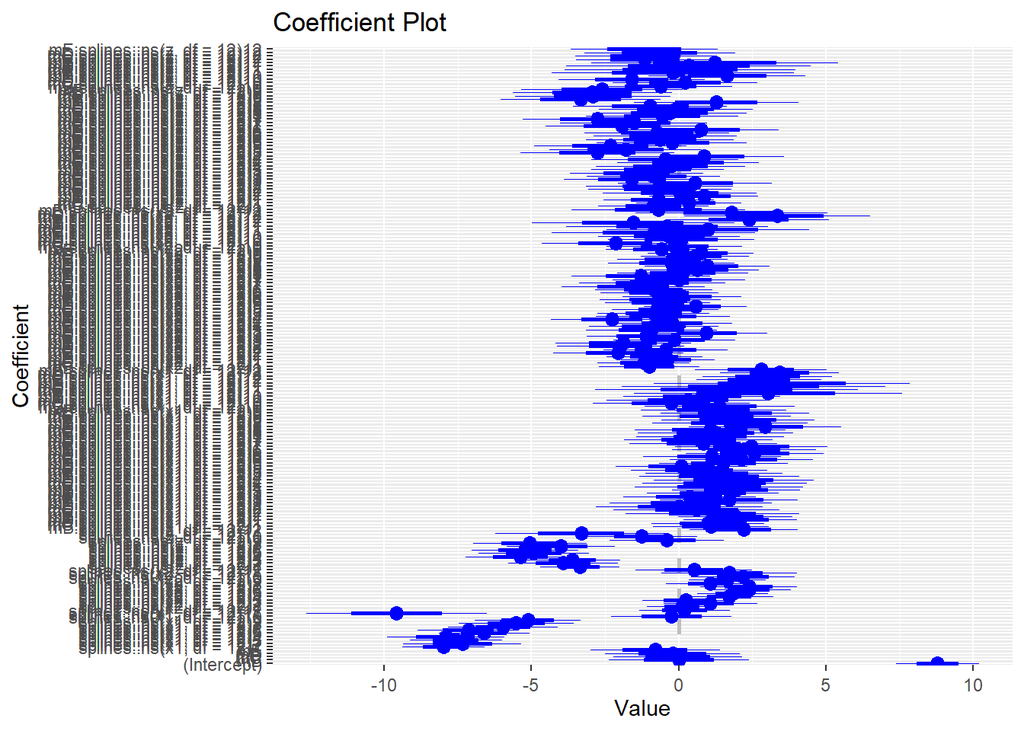

```r
coefplot::coefplot(basis_1)
coefplot::coefplot(basis_2)
coefplot::coefplot(basis_3)
```

The polynomial model denotes x1^2 and x2^2 as the most significant values, reaching up to +/- 40. The first spline model generally weights x1 and z higher than x2, and its coefficients are all within +/- 8. The big spline model has many insignificant terms, but also a similar range for coefficients and high weights on x1.

**PART 2: BAYESIAN MODELS**

Let’s put a prior on basis fn models 1 and 2, since they performed best.

```r
library(rstanarm)
bayesian_model_polynomial <- stan_glm(formula = y ~ x1 + x2 + x5 + z + v5 + I(x1^2) + I(x2^2) + I(x5^2) + I(z^2) + I(v5^2), data = df, prior = normal(location = 0, scale = 5), seed = 999, verbose = FALSE)
bayesian_model_spline <- stan_glm(formula = y ~ splines::ns(x1, df = 12) + splines::ns(x2, df = 12) + splines::ns(z, df = 12), data = df, prior = normal(location = 0, scale = 2.5), seed = 999, verbose = FALSE)
```

**Compare Polynomial LM and Bayesian**

```r
summary(bayesian_model_polynomial)
```

```
##
## Model Info:
##  function:     stan_glm
##  family:       gaussian [identity]
##  formula:      y ~ x1 + x2 + x5 + z + v5 + I(x1^2) + I(x2^2) + I(x5^2) + I(z^2) +
##     I(v5^2)
##  algorithm:    sampling
##  sample:       4000 (posterior sample size)
##  priors:       see help('prior_summary')
##  observations: 1252
##  predictors:   11
##
## Estimates:
##               mean   sd    10%   50%   90%
## (Intercept)   1.8    0.5   1.1   1.8   2.5
## x1          -14.0    1.2 -15.5 -14.0 -12.5
## x2           10.6    1.3   9.0  10.6  12.3
## x5           -1.4    1.8  -3.7  -1.4   0.9
## z            -2.8    0.3  -3.3  -2.8  -2.4
## v5           -0.1    0.1  -0.1  -0.1   0.0
## I(x1^2)      33.4    1.5  31.4  33.4  35.4
## I(x2^2)     -16.5    3.0 -20.3 -16.5 -12.5
## I(x5^2)       2.7    1.6   0.7   2.7   4.7
## I(z^2)        0.7    0.0   0.6   0.7   0.8
## I(v5^2)       0.0    0.0   0.0   0.0   0.0
## sigma         1.4    0.0   1.4   1.4   1.4
##
## Fit Diagnostics:
##            mean   sd   10%   50%   90%
## mean_PPD 0.5    0.1  0.5   0.5   0.6
##
## The mean_ppd is the sample average posterior predictive distribution of the outcome variable (for details see help('summary.stanreg')).
##
## MCMC diagnostics
##               mcse Rhat n_eff
## (Intercept)   0.0  1.0  1938
## x1            0.0  1.0  1982
## x2            0.0  1.0  2493
## x5            0.0  1.0  1538
## z             0.0  1.0  1448
## v5            0.0  1.0  3831
## I(x1^2)       0.0  1.0  2896
## I(x2^2)       0.1  1.0  3362
## I(x5^2)       0.0  1.0  1756
## I(z^2)        0.0  1.0  1614
## I(v5^2)       0.0  1.0  3826
## sigma         0.0  1.0  3916
## mean_PPD      0.0  1.0  3807
## log-posterior 0.1  1.0  1600
##
## For each parameter, mcse is Monte Carlo standard error, n_eff is a crude measure of effective sample size, and Rhat is the potential scale reduction factor on split chains (at convergence Rhat=1).
```

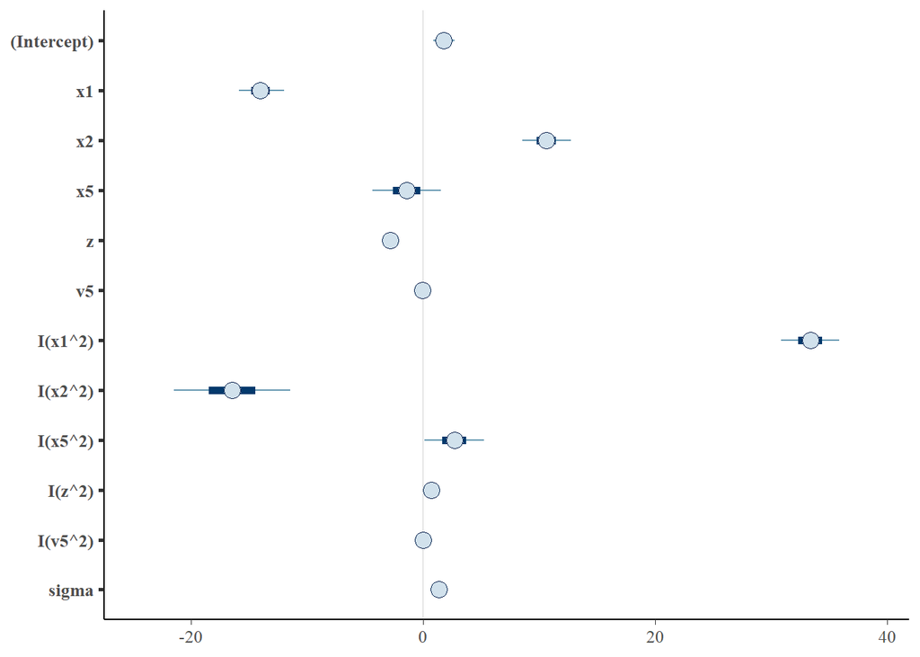

```r
plot(bayesian_model_polynomial)
```

```r
coefplot::coefplot(basis_1)
loo(bayesian_model_polynomial)
```

```
##
## Computed from 4000 by 1252 log-likelihood matrix
##
##          Estimate   SE
## elpd_loo  -2205.2 30.1
## p_loo        14.5  1.1
## looic      4410.3 60.2
## ------
## Monte Carlo SE of elpd_loo is 0.1.
##
## All Pareto k estimates are good (k < 0.5).
## See help('pareto-k-diagnostic') for details.
```

**Compare Spline LM and Bayesian Spline**

```r
summary(bayesian_model_spline)
```

```
##
## Model Info:
##  function:     stan_glm
##  family:       gaussian [identity]
##  formula:      y ~ splines::ns(x1, df = 12) + splines::ns(x2, df = 12) + splines::ns(z,
##     df = 12)
##  algorithm:    sampling
##  sample:       4000 (posterior sample size)
##  priors:       see help('prior_summary')
##  observations: 1252
##  predictors:   37
##
## Estimates:
##                              mean   sd   10%   50%   90%
## (Intercept)                 7.8    0.3  7.3   7.8   8.2
## splines::ns(x1, df = 12)1  -6.6    0.3 -7.0  -6.6  -6.2
## splines::ns(x1, df = 12)2  -6.1    0.4 -6.6  -6.1  -5.6
## splines::ns(x1, df = 12)3  -6.2    0.3 -6.7  -6.2  -5.8
## splines::ns(x1, df = 12)4  -5.9    0.4 -6.4  -5.9  -5.5
## splines::ns(x1, df = 12)5  -5.5    0.3 -5.9  -5.5  -5.0
## splines::ns(x1, df = 12)6  -5.0    0.3 -5.4  -5.0  -4.6
## splines::ns(x1, df = 12)7  -4.4    0.3 -4.9  -4.4  -4.0
## splines::ns(x1, df = 12)8  -3.5    0.3 -4.0  -3.5  -3.1
## splines::ns(x1, df = 12)9  -3.4    0.3 -3.9  -3.4  -3.0
## splines::ns(x1, df = 12)10  0.5    0.3  0.1   0.5   0.9
## splines::ns(x1, df = 12)11 -6.1    0.6 -6.9  -6.1  -5.3
## splines::ns(x1, df = 12)12  2.3    0.3  1.9   2.3   2.7
## splines::ns(x2, df = 12)1  -0.6    0.2 -0.9  -0.6  -0.3
## splines::ns(x2, df = 12)2  -0.2    0.3 -0.6  -0.2   0.2
## splines::ns(x2, df = 12)3   0.0    0.3 -0.3   0.0   0.4
## splines::ns(x2, df = 12)4   0.7    0.3  0.3   0.7   1.1
## splines::ns(x2, df = 12)5   1.6    0.3  1.3   1.6   2.0
## splines::ns(x2, df = 12)6   1.9    0.3  1.5   1.9   2.3
## splines::ns(x2, df = 12)7   1.7    0.3  1.3   1.7   2.2
## splines::ns(x2, df = 12)8   1.3    0.3  0.9   1.3   1.7
## splines::ns(x2, df = 12)9   1.7    0.3  1.4   1.7   2.1
## splines::ns(x2, df = 12)10  1.5    0.3  1.1   1.5   2.0
## splines::ns(x2, df = 12)11  1.3    0.5  0.7   1.3   1.9
## splines::ns(x2, df = 12)12  1.7    0.4  1.2   1.7   2.3
## splines::ns(z, df = 12)1   -3.2    0.3 -3.5  -3.2  -2.9
```

[output cut: 48 more lines]

```
## splines::ns(z, df = 12)3   0.0  1.0  1161
## splines::ns(z, df = 12)4   0.0  1.0  1160
## splines::ns(z, df = 12)5   0.0  1.0  1064
## splines::ns(z, df = 12)6   0.0  1.0   956
## splines::ns(z, df = 12)7   0.0  1.0   889
## splines::ns(z, df = 12)8   0.0  1.0  1025
## splines::ns(z, df = 12)9   0.0  1.0   923
## splines::ns(z, df = 12)10  0.0  1.0  1133
## splines::ns(z, df = 12)11  0.0  1.0   893
## splines::ns(z, df = 12)12  0.0  1.0  1332
## sigma                      0.0  1.0  6191
## mean_PPD                   0.0  1.0  5141
## log-posterior              0.1  1.0  1561
##
## For each parameter, mcse is Monte Carlo standard error, n_eff is a crude measure of effective sample size, and Rhat is the potential scale reduction factor on split chains (at convergence Rhat=1).
```

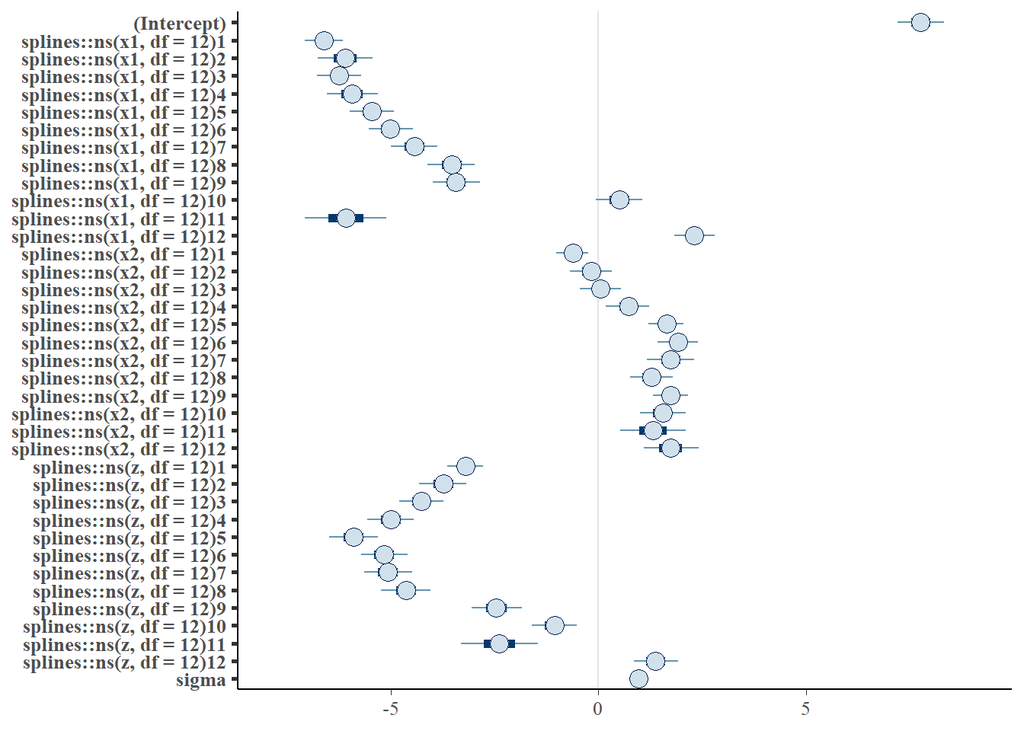

```r
plot(bayesian_model_spline)
```

```r
coefplot::coefplot(basis_2)
loo(bayesian_model_spline)
```

```
##
## Computed from 4000 by 1252 log-likelihood matrix
##
##          Estimate   SE
## elpd_loo  -1756.8 25.5
## p_loo        40.1  1.9
## looic      3513.5 51.0
## ------
## Monte Carlo SE of elpd_loo is 0.1.
##
## All Pareto k estimates are good (k < 0.5).
## See help('pareto-k-diagnostic') for details.
```

We can see that the coefficients are slightly constrained towards 0, but the difference between Bayesian and LM models isn’t as large as I expected. To evaluate the stan_lm models, I used Leave One Out Information Criterion, which I understand is analogous to AIC. Using this metric, the Bayesian model based on splines is significantly better than the one based on polynomials. I’m not sure if we can directly compare AIC and LOOIC, but if we could, the non-Bayesian spline model would still be best, slightly edging out the Bayesian spline model.

**Model Predictions:** Let’s use our two best LM() models.. Let’s use x1 and x2 as our inputs. They’re consistently significant, and I don’t want to use Z since it derives from x1 and x2.

define prediction function:

```r
tidy_predict <- function(mod, xnew)
{
  pred_df <- predict(mod, xnew, interval = "confidence") %>%
    as.data.frame() %>% tibble::as_tibble() %>%
    dplyr::select(pred = fit, ci_lwr = lwr, ci_upr = upr) %>%
    bind_cols(predict(mod, xnew, interval = 'prediction') %>%
                as.data.frame() %>% tibble::as_tibble() %>%
                dplyr::select(pred_lwr = lwr, pred_upr = upr))

  xnew %>% bind_cols(pred_df)
}
```

**Polynomial basis fn model**

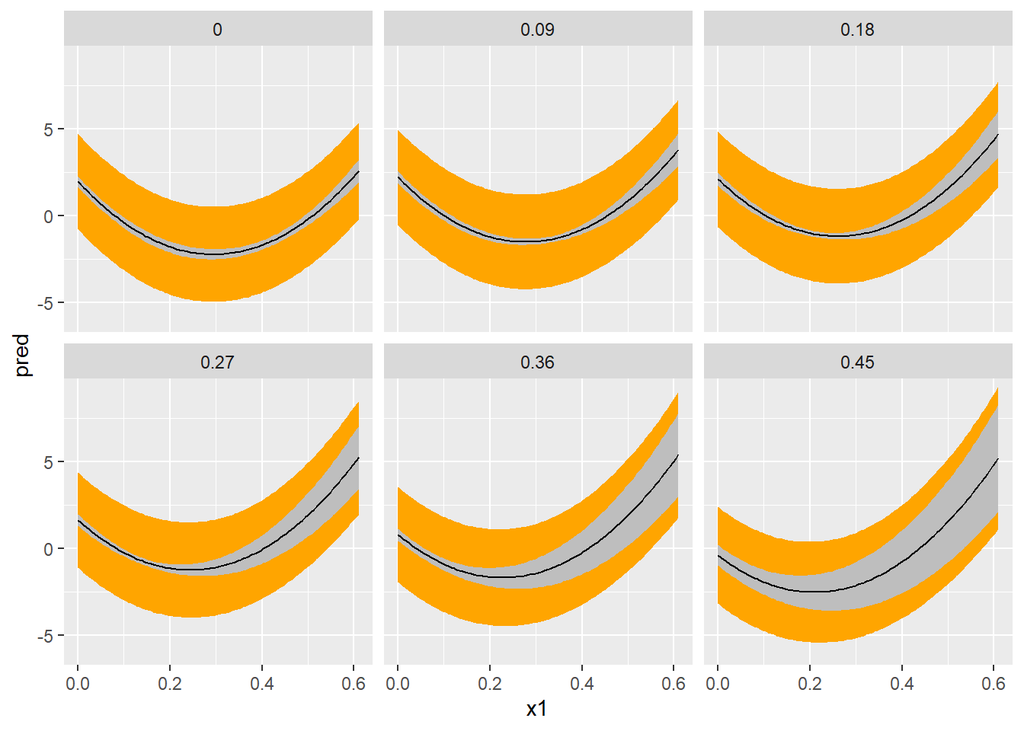

```r
viz_grid <- expand.grid(x1 = seq(from = 0.0, to = 0.61, length.out = 101),
                        x2 = seq(from = 0.0, to = 0.45, length.out = 6),

                        KEEP.OUT.ATTRS = FALSE) %>%
  as.data.frame() %>% tibble::as_tibble() %>% mutate( x5 = 1 - (x1 + x2 + median(df$x3) + median(df$x4)),
                        z = (x1 + x2)/(median(df$x3) + median(df$x4)),
                        v5 = median(df$v5))

pred_poly_basis <- tidy_predict(basis_1, viz_grid)
pred_poly_basis %>% ggplot(mapping = aes(x = x1)) + geom_ribbon(mapping = aes(ymin = pred_lwr, ymax = pred_upr), fill = "orange") + geom_ribbon(mapping = aes(ymin = ci_lwr, ymax = ci_upr), fill = 'grey') + geom_line(mapping = aes(y = pred))+ facet_wrap(pred_poly_basis$x2) + coord_cartesian(ylim = c(-6,9))
```

Interesting results.. A positive quadratic relationship exists between the logit-transformed output Y and the input x1. This alighs with the large positive coefficient found on x1^2 in our basis fn model. Interestingly, as x2 gets larger, our condifence interval w.r.t. x1 widens and moves higher, especially at higher values of x1. Furthermore, the predictions are overall higher at middle values of x2, and lower at low or high values of x2, reflecting the negative quadratic relaitonship between Y and x2.

**Spline Basis model**

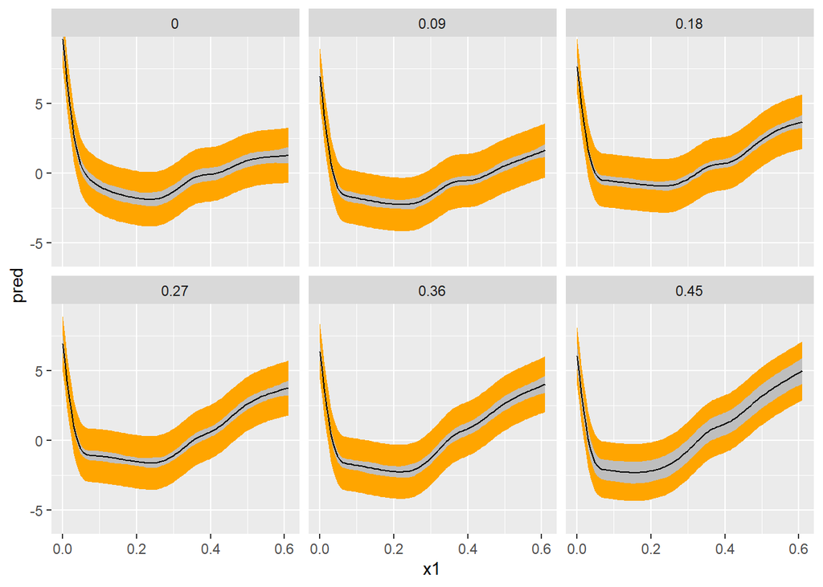

```r
viz_grid_2 <- expand.grid(x1 = seq(from = 0.0, to = 0.61, length.out = 101),
                        x2 = seq(from = 0.0, to = 0.45, length.out = 6),
                        KEEP.OUT.ATTRS = FALSE)  %>%
  as.data.frame() %>% tibble::as_tibble() %>% mutate(z = (x1 + x2)/(median(df$x3) + median(df$x4)))
pred_spline_basis <- tidy_predict(basis_2, viz_grid_2)
pred_spline_basis %>% ggplot(mapping = aes(x = x1)) + geom_ribbon(mapping = aes(ymin = pred_lwr, ymax = pred_upr), fill = "orange") + geom_ribbon(mapping = aes(ymin = ci_lwr, ymax = ci_upr), fill = 'grey') + geom_line(mapping = aes(y = pred))+ facet_wrap(pred_spline_basis$x2) + coord_cartesian(ylim = c(-6,9))
```

**Wow, definitely a more complicated curve. Still concave up, but with a sharp decline from x1=0 to x1=.05, then a gradual rise. Again, increasing values of x2 widen the confidence interval (but not the prediction interval) and shift the output up at higher values of x1. Based on this visualization, x1 of around .25 and x2 of .36 lead to the best results. I suspect the spline model is better than the polynomial since it can generate more complex curves as shown above.**